# ERP model

## Position Van Petten and Kutas

```r
write("vanpetten", stderr())
pos.df = subset(adultdata.df,  str_detect(adultdata.df$Condition,"(CONG|INCOH)")) # & tick < 10)

print(head(pos.df[pos.df$measure=="target",c("word","wordcat","Condition","Example","tick")])) # check
```

```
##         word wordcat Condition                                     Example
## 106913   man   NOUNA      CONG  man -s throw -ed the toy to the driver . .
## 106926    -s      PL      CONG  man -s throw -ed the toy to the driver . .
## 106939 throw   VERBD      CONG  man -s throw -ed the toy to the driver . .
## 106952   -ed      ED      CONG  man -s throw -ed the toy to the driver . .
## 106965   the     DET      CONG  man -s throw -ed the toy to the driver . .
## 106978   toy   NOUNI      CONG  man -s throw -ed the toy to the driver . .
##        tick
## 106913    1
## 106926    2
## 106939    3
## 106952    4
## 106965    5
## 106978    6
```

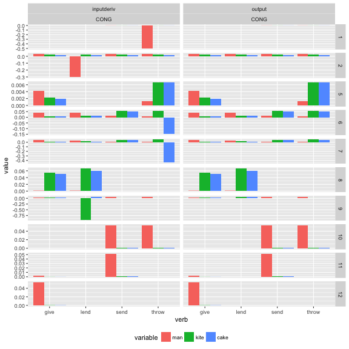

```r
postargword.df = subset(pos.df, layer %in% c("word") & measure %in% c("output",mainMeasure) & contfunc=="C" & wordcat != "VERBD" & Condition == "CONG")
postargword.df$verb = str_match(postargword.df$Example,"(give|throw|send|lend)")[,2]
meanbyword = aggregate(cbind(man,kite,cake) ~ tick + measure + verb + Condition,postargword.df, mean)
meanbywordlong= melt(meanbyword,id.var=1:4)

p1 = ggplot(meanbywordlong, aes(x=verb, y=value, fill = variable))
p1 = p1 + geom_bar(stat="identity",position="dodge")
#p1 = p1 + facet_wrap(~ measure + tick,scales = "free",ncol=4)
p1 = p1 + facet_grid( tick ~ measure + Condition,scales = "free_y")
p1 = p1 + theme(legend.position="bottom")
p1
```

```r
# this is for creating ERP figure
nooutput = subset(pos.df, ! measure %in% layerNotERP)
end = which(names(nooutput)=="depth")-1
first = which(names(nooutput)=="none")
norawpos.df = nooutput[,-(first:end)] # remove word specific activations/error
norawpos.df$Condition = factor(norawpos.df$Condition,labels=c("Congruent","Syntactic"))

dvlen = length(names(norawpos.df))- which(names(norawpos.df)=="depth")
longnoraw= melt(norawpos.df,id.var=1:(length(norawpos.df)-dvlen)) # make long format

# add target layer for figure
longnoraw2 = subset(longnoraw, measure == mainMeasure & contfunc == "C") #& wordcat != "VERBD"
#longnoraw2$contfunc = paste(longnoraw2$tick,longnoraw2$contfunc)
mapping = aes(x=depth, y=value, colour = Condition,linetype=Condition)
p1= drawERP(longnoraw2,mapping, timesize=-1)
```

```
## [1] 6
```

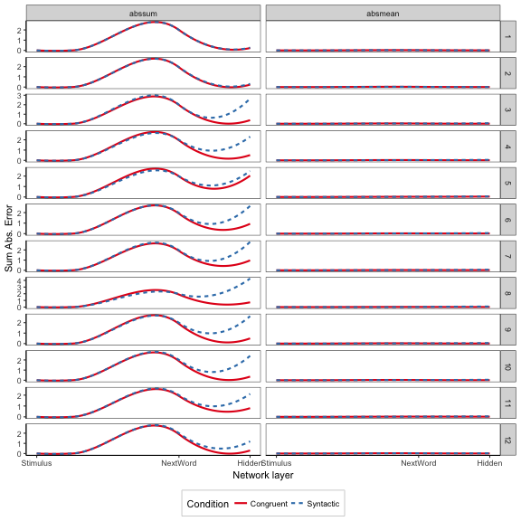

```r
p1 = p1 + facet_grid(tick ~ variable ,scales = "free")
#p1 = p1 + facet_wrap( ~ tick+variable)
p1
```

```r
interactionText=""
# get example for table
tablesub = subset(norawpos.df,layer == "word" & measure == mainMeasure & tick == 2)
exampleTable = tablesub[1:4,c("Condition","Example")]
tabletext = kable(exampleTable,format="latex",row.names=FALSE)
print(exampleTable)
```

```
##        Condition                                            Example
## 106928 Congruent         man -s throw -ed the toy to the driver . .
## 107071 Syntactic         steak -s throw -ed the man to the kite . .
## 107630 Congruent  the father was lend -ing a sister the kite -s . .
## 107786 Syntactic   the ball was lend -ing a coffee the woman -s . .
```

```r
posinput  = subset(norawpos.df,measure == mainMeasure & layer %in% c("word",p600layer) & word != "." & contfunc=="C" & wordcat %in% c("NOUNA","NOUNI"))
#posinput = subset(posinput, !str_detect(Example,"-par") )

if (nlevels(adultdata.df$sub) > 4){ # do mixed with more than 9 subj
  print("run models")
  # our analysis uses this set

  posinput$dcoher = ifelse(posinput$Condition=="Congruent",1,0)
  posinput$ccoher = ifelse(posinput$Condition=="Congruent",0.5,-0.5)
  posinput$cword = ifelse(posinput$layer=="word",0.5,-0.5)
  posinput$ctick = posinput$tick - mean(posinput$tick)
  posinput$ccontent = ifelse(posinput$contfunc=="C",0.5,-0.5)
#& wordcat != "VERBD"
  posinputnoun = subset(posinput, layer == "word")
  randomeff = paste(" + (1 + dcoher*ctick |sub)")
  if (noslopes){ randomeff = " + (1 | sub)"}
  formu = as.formula(paste(dependMeasure,"~ dcoher*ctick",randomeff ))
  omnimodel = lmer(formu, posinputnoun,control=lmerControl(optimizer = "bobyqa",optCtrl=list(maxfun=50000)))
  print(summary(omnimodel))

  modellist = modelComparison(omnimodel) # create anova table by terms subtraction

  # create figure for paper
}
```

```
## [1] "run models"
## Linear mixed model fit by REML ['lmerMod']
## Formula: abssum ~ dcoher * ctick + (1 + dcoher * ctick | sub)
##    Data: posinputnoun
## Control: lmerControl(optimizer = "bobyqa", optCtrl = list(maxfun = 50000))
##
## REML criterion at convergence: -7090.2
##
## Scaled residuals:
##     Min      1Q  Median      3Q     Max
## -6.5023 -0.4530  0.0886  0.4666  3.6429
##
## Random effects:
##  Groups   Name         Variance  Std.Dev. Corr
##  sub      (Intercept)  3.644e-06 0.001909
##           dcoher       2.932e-05 0.005414 -1.00
##           ctick        7.671e-08 0.000277  1.00 -1.00
##           dcoher:ctick 1.797e-06 0.001341 -1.00  1.00 -1.00
##  Residual              1.103e-03 0.033215
## Number of obs: 1800, groups:  sub, 10
##
## Fixed effects:
##                Estimate Std. Error t value
## (Intercept)   1.9710800  0.0012610  1563.0
## dcoher       -0.0583900  0.0023202   -25.2
## ctick         0.0040394  0.0003498    11.5
## dcoher:ctick -0.0109311  0.0006396   -17.1
##
## Correlation of Fixed Effects:
##             (Intr) dcoher ctick
## dcoher      -0.772
## ctick        0.120 -0.185
## dcoher:ctck -0.317  0.489 -0.679
## [1] "remove . ~ . -  dcoher:ctick "
```

```
## refitting model(s) with ML (instead of REML)
```

```
## Data: posinputnoun
## Models:
## model2: abssum ~ dcoher + ctick + (1 + dcoher * ctick | sub)
## model: abssum ~ dcoher * ctick + (1 + dcoher * ctick | sub)
##        Df     AIC     BIC logLik deviance  Chisq Chi Df Pr(>Chisq)
## model2 14 -7077.1 -7000.1 3552.5  -7105.1
## model  15 -7110.9 -7028.5 3570.4  -7140.9 35.824      1   2.16e-09 ***
## ---
## Signif. codes:  0 '***' 0.001 '**' 0.01 '*' 0.05 '.' 0.1 ' ' 1
## [1] "########## Above comparison for  dcoher:ctick  *** "
## [1] "remove . ~ . -  ctick "
```

```
## refitting model(s) with ML (instead of REML)
```

```
## Data: posinputnoun
## Models:
## model2: abssum ~ dcoher + (1 + dcoher * ctick | sub)
## model: abssum ~ dcoher + ctick + (1 + dcoher * ctick | sub)
##        Df     AIC     BIC logLik deviance  Chisq Chi Df Pr(>Chisq)
## model2 13 -7079.0 -7007.5 3552.5  -7105.0
## model  14 -7077.1 -7000.1 3552.5  -7105.1 0.0863      1      0.769
## [1] "########## Above comparison for  ctick "
## [1] "remove . ~ . -  dcoher "
```

```
## refitting model(s) with ML (instead of REML)
```

```
## Data: posinputnoun
## Models:
## model2: abssum ~ (1 + dcoher * ctick | sub)
## model: abssum ~ dcoher + (1 + dcoher * ctick | sub)
##        Df     AIC     BIC logLik deviance  Chisq Chi Df Pr(>Chisq)
## model2 12 -7062.3 -6996.4 3543.2  -7086.3
## model  13 -7079.0 -7007.5 3552.5  -7105.0 18.673      1  1.552e-05 ***
## ---
## Signif. codes:  0 '***' 0.001 '**' 0.01 '*' 0.05 '.' 0.1 ' ' 1
## [1] "########## Above comparison for  dcoher  *** "
```

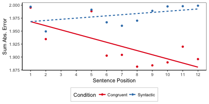

```r
# & wordcat != "VERBD"
  longnoraw2 = subset(posinput,  layer == "word" )
  form = as.formula(paste(dependMeasure," ~ tick + Condition",sep=""))
  mdf = aggregate(form, longnoraw2, mean)
  mapping = aes_string(x="tick", y=dependMeasure, colour = "Condition",linetype="Condition")
  p1 = ggplot(mdf,mapping=mapping)
  #p1 = p1 + geom_line() + geom_point()
  p1 = p1 + geom_point()
  p1 = p1 + stat_smooth(method="lm",se=F)
  p1 = p1 + scale_colour_brewer( palette="Set1")
  p1 = p1 + scale_x_continuous(breaks=1:12)
  p1 = p1 + theme_bw()
  p1 = p1 +theme(legend.background = element_rect(size=.4, color="grey80"))
  p1=p1 + theme(legend.position="bottom")+xlab("Sentence Position")+ylab("Sum Abs. Error")
  p1 = p1 + theme(panel.grid.major = element_blank(),
                  panel.grid.minor = element_blank(),
                  panel.background = element_blank(),
                  axis.line = element_line(colour = "black"))
  cong = str_split(exampleTable$Example[1]," ")[[1]]
  inco = str_split(exampleTable$Example[2]," ")[[1]]

coindf = data.frame(tick=rep(1:9,2),word=c(cong[2:10],inco[2:10]),Condition=rep(c("Congruent","Incoherent"),each=9),dependMeasure=rep(c(1.9,1.97),each=9))

#   p1=p1+geom_text(aes(x=tick, y= dependMeasure,label=word,colour = Condition),coindf,size=3)
p1
```

```r
  if (!noslopes){ # when doing final version, change noslopes to FALSE
    ggsave("img/vanpetten.png",width=figwidth,height=figheight) # control font size with height/width
  }
```

CUT AND PASTE INTO LATEX DOC click in box and use right arrow to see whole text

```latex
Need stats to explain this

This is an example of the stimuli used in the model

\begin{tabular}{l|l}
\hline
Condition & Example\\
\hline
Congruent & man -s throw -ed the toy to the driver . .\\
\hline
Syntactic & steak -s throw -ed the man to the kite . .\\
\hline
Congruent & the father was lend -ing a sister the kite -s . .\\
\hline
Syntactic & the ball was lend -ing a coffee the woman -s . .\\
\hline
\end{tabular}
The maximal model for the data had random slopes  + (1 + dcoher*ctick |sub)

Mixed Model Results
a main effect of dcoher ($\beta$=-0.058, SE=0.0023, $\chi^2$(1)=18.67, p<0.001)
no main effect of ctick ($\beta$=0.004, SE=0.00035, $\chi^2$(1)=0.09, p=0.769)
@@ @@an interaction of dcoher:ctick ($\beta$=-0.011, SE=0.00064, $\chi^2$(1)=35.82, p<0.001)
```

## AGREEMENT Hagoort et al 1993

```r
# This is Hagoort et al 1993
write("agree", stderr())
agree.df = subset(adultdata.df,  str_detect(Condition,"(PLUR|SING)") )
verbpos = which(agree.df$wordcat == "VERBT")
wordcatsamelen = which(agree.df$wordcat!=agree.df$wordcat[1])[1]-1
verb.df = agree.df[verbpos,] #  verb
postverb.df = agree.df[verbpos + wordcatsamelen,] # position after verb
postverb.df=postverb.df[!is.na(postverb.df$Condition),]

cond = str_split_fixed(postverb.df$Condition,";",2)
postverb.df$Number = cond[,1]
postverb.df$Agreement = cond[,2]
postverb.df$Number = factor(postverb.df$Number,labels=c("Plural","Singular"))
postverb.df$Agreement = factor(postverb.df$Agreement,labels=c("Control","Violation"))
nc = length(postverb.df)
postverb.df = postverb.df[,c(nc-1,nc,1:(nc-2))]
xtabs(~ Agreement + Number ,postverb.df)
```

```
##            Number
## Agreement   Plural Singular
##   Control     3000     3000
##   Violation   3000     3000
```

```r
print(head(postverb.df[postverb.df$measure=="target",c("word","wordcat","Condition","Example","tick")])) # check
```

```
##        word wordcat Condition                              Example tick
## 107251    a     DET PLUR;CONT          the boy -s take a stick . .    5
## 107355  -ss      SS PLUR;VIOL      the boy -s take -ss a stick . .    5
## 107459  -ss      SS SING;CONT         the boy take -ss a stick . .    4
## 107563    a     DET SING;VIOL             the boy take a stick . .    4
## 110319 wine   NOUNI PLUR;CONT      the father -s taste wine -s . .    5
## 110423  -ss      SS PLUR;VIOL  the father -s taste -ss wine -s . .    5
```

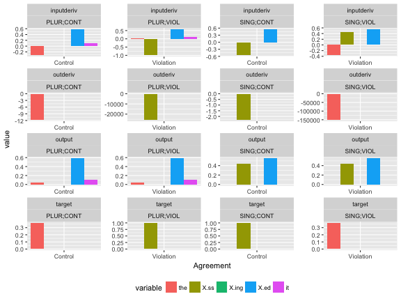

```r
showWordOutError("the,X.ss,X.ing,X.ed,it",c("Agreement","measure","Condition"),postverb.df)
```

- this hidden code below is used to understand how the error appears for individual units, but I've turned it off to keep things simple

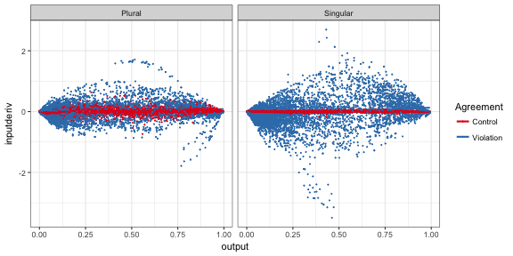

```r
corrHiddenOutputInputDeriv(postverb.df,"Agreement","Number")
```

```r
# make erp figure with different measures
mapping = aes(x=depth, y=value, colour = Number,linetype=Agreement)
norawpostverbnotargout.df=removeWordsDrawERP(postverb.df,mapping)
```

```
## [1] 6
```

```r
interactionText="NO TEXT"
modellist2 = list()

# get example for table
agreeinputword = subset(norawpostverbnotargout.df,measure == mainMeasure  & layer == "word")
exampleTable = agreeinputword[1:4,c("Number","Agreement","Example")]
tabletext = kable(exampleTable,format="latex",row.names=FALSE)
print(exampleTable)
```

```
##          Number Agreement                          Example
## 107253   Plural   Control      the boy -s take a stick . .
## 107357   Plural Violation  the boy -s take -ss a stick . .
## 107461 Singular   Control     the boy take -ss a stick . .
## 107565 Singular Violation         the boy take a stick . .
```

```r
agreeinput  = subset(norawpostverbnotargout.df,measure == mainMeasure & layer %in% c("word",p600layer) )

if (nlevels(adultdata.df$sub) > 4){ # do mixed with more than 9 subj

  agreeinput$cplural = ifelse(agreeinput$Number=="Plural",0.5,-0.5)
  agreeinput$cviolation = ifelse(agreeinput$Agreement=="Violation",0.5,-0.5)
  agreeinput$cp6layer = ifelse(agreeinput$layer==p600layer,0.5,-0.5)

  # this is the main mixed model with centered variables
    randomeff = paste(" + (1 + cviolation*cp6layer |sub)")  #Agreement * layer
      if (noslopes){ randomeff = " + (1 | sub)"}
  formu = as.formula(paste(dependMeasure,"~ cviolation*cp6layer",randomeff))
  omnimodel = lmer(formu, agreeinput,control=lmerControl(optimizer = "bobyqa",optCtrl=list(maxfun=50000)))
  print(summary(omnimodel))
  modellist2 = modelComparison(omnimodel) # create anova table
  # this model is for posthocs
  formu2 = as.formula(paste(dependMeasure,"~ Agreement*layer",randomeff))
  omnimodelFactor = lmer(formu2, agreeinput)
  #print(summary(omnimodelFactor))
  model.lsmobj <- lsmeans(omnimodelFactor, ~ Agreement | layer)
  posthocs = summary(as.glht(pairs(model.lsmobj)))
  print(posthocs)
  interactionText = printInteraction(posthocs)

}
```

```
## Linear mixed model fit by REML ['lmerMod']
## Formula: abssum ~ cviolation * cp6layer + (1 + cviolation * cp6layer |
##     sub)
##    Data: agreeinput
## Control: lmerControl(optimizer = "bobyqa", optCtrl = list(maxfun = 50000))
##
## REML criterion at convergence: 7649.2
##
## Scaled residuals:
##     Min      1Q  Median      3Q     Max
## -4.4173 -0.3718  0.0001  0.2489  5.2085
##
## Random effects:
##  Groups   Name                Variance Std.Dev. Corr
##  sub      (Intercept)         0.1700   0.4123
##           cviolation          0.6324   0.7953   0.97
##           cp6layer            0.6334   0.7959   1.00 0.98
##           cviolation:cp6layer 2.6656   1.6327   0.98 1.00 0.99
##  Residual                     1.3812   1.1752
## Number of obs: 2400, groups:  sub, 10
##
## Fixed effects:
##                     Estimate Std. Error t value
## (Intercept)           2.9028     0.1326  21.896
## cviolation            3.4526     0.2560  13.486
## cp6layer              2.3568     0.2562   9.198
## cviolation:cp6layer   5.8037     0.5251  11.052
##
## Correlation of Fixed Effects:
##             (Intr) cviltn cp6lyr
## cviolation  0.934
## cp6layer    0.965  0.942
## cvltn:cp6ly 0.946  0.965  0.952
## [1] "remove . ~ . -  cviolation:cp6layer "
```

```
## refitting model(s) with ML (instead of REML)
```

```
## Data: agreeinput
## Models:
## model2: abssum ~ cviolation + cp6layer + (1 + cviolation * cp6layer |
## model2:     sub)
## model: abssum ~ cviolation * cp6layer + (1 + cviolation * cp6layer |
## model:     sub)
##        Df    AIC    BIC  logLik deviance  Chisq Chi Df Pr(>Chisq)
## model2 14 7692.5 7773.4 -3832.2   7664.5
## model  15 7667.7 7754.4 -3818.8   7637.7 26.775      1  2.286e-07 ***
## ---
## Signif. codes:  0 '***' 0.001 '**' 0.01 '*' 0.05 '.' 0.1 ' ' 1
## [1] "########## Above comparison for  cviolation:cp6layer  *** "
## [1] "remove . ~ . -  cp6layer "
```

```
## refitting model(s) with ML (instead of REML)
```

```
## Data: agreeinput
## Models:
## model2: abssum ~ cviolation + (1 + cviolation * cp6layer | sub)
## model: abssum ~ cviolation + cp6layer + (1 + cviolation * cp6layer |
## model:     sub)
##        Df    AIC    BIC  logLik deviance  Chisq Chi Df Pr(>Chisq)
## model2 13 7691.8 7767.0 -3832.9   7665.8
## model  14 7692.5 7773.4 -3832.2   7664.5 1.3736      1     0.2412
## [1] "########## Above comparison for  cp6layer "
## [1] "remove . ~ . -  cviolation "
```

```
## refitting model(s) with ML (instead of REML)
```

```
## Data: agreeinput
## Models:
## model2: abssum ~ (1 + cviolation * cp6layer | sub)
## model: abssum ~ cviolation + (1 + cviolation * cp6layer | sub)
##        Df    AIC    BIC  logLik deviance  Chisq Chi Df Pr(>Chisq)
## model2 12 7697.5 7766.9 -3836.7   7673.5
## model  13 7691.8 7767.0 -3832.9   7665.8 7.6503      1   0.005676 **
## ---
## Signif. codes:  0 '***' 0.001 '**' 0.01 '*' 0.05 '.' 0.1 ' ' 1
## [1] "########## Above comparison for  cviolation  *** "
```

```
## Note: df set to 9
```

```
## $`layer = word`
##
##   Simultaneous Tests for General Linear Hypotheses
##
## Linear Hypotheses:
##                          Estimate Std. Error t value Pr(>|t|)
## Control - Violation == 0 -0.55076    0.06926  -7.953 2.32e-05 ***
## ---
## Signif. codes:  0 '***' 0.001 '**' 0.01 '*' 0.05 '.' 0.1 ' ' 1
## (Adjusted p values reported -- single-step method)
##
##
## $`layer = hidden`
##
##   Simultaneous Tests for General Linear Hypotheses
##
## Linear Hypotheses:
##                          Estimate Std. Error t value Pr(>|t|)
## Control - Violation == 0   -6.354      0.514  -12.36 5.97e-07 ***
## ---
## Signif. codes:  0 '***' 0.001 '**' 0.01 '*' 0.05 '.' 0.1 ' ' 1
## (Adjusted p values reported -- single-step method)
```

```
## [1] 6
```

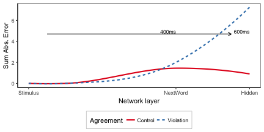

```r
  # figure for paper
 mapping = aes_string(x="depth", y=dependMeasure, colour = "Agreement",linetype="Agreement")
  drawERP(agreeinput,mapping, span=1, timeline.y=4.7)
```

```r
  if (!noslopes){ # when doing final version, change noslopes to FALSE
    ggsave("img/agree.png",width=figwidth,height=figheight)
  }
```

CUT AND PASTE INTO LATEX DOC click in box and use right arrow to see whole text

```latex
The model received active transitive input with singular subjects 75\% of the time and plural subjects 25\% of the time.

This is an example of the stimuli used in the model.


\begin{tabular}{l|l|l}
\hline
Number & Agreement & Example\\
\hline
Plural & Control & the boy -s take a stick . .\\
\hline
Plural & Violation & the boy -s take -ss a stick . .\\
\hline
Singular & Control & the boy take -ss a stick . .\\
\hline
Singular & Violation & the boy take a stick . .\\
\hline
\end{tabular}
The maximal model for the data had random slopes  + (1 + cviolation*cp6layer |sub)

Mixed Model Results
a main effect of cviolation ($\beta$=3.5, SE=0.26, $\chi^2$(1)=7.65, p=0.0057)
no main effect of cp6layer ($\beta$=2.4, SE=0.26, $\chi^2$(1)=1.37, p=0.241)
@@an interaction of cviolation:cp6layer ($\beta$=5.8, SE=0.53, $\chi^2$(1)=26.78, p<0.001)
Posthoc tests for each layer
 @@Posthoc: There was a significant difference for layer = word, diff = 0.5508, t(9)=7.95, p<0.001
 @@Posthoc: There was a significant difference for layer = hidden, diff = 6.3545, t(9)=12.36, p<0.001
ratio  layer = hidden   11.5368554829339  rev  0.0866787316075222
```

## Tense Allen et al. (2003)

```r
write("tense", stderr())
tense.df = subset(adultdata.df,  str_detect(Condition,"(TENSECONT|TENSEVIOL)") )
tense.df$Condition = factor(tense.df$Condition,labels=c("Control","Violation"))
verbpos = which(tense.df$wordcat == "VERBT")
wordcatsamelen = which(tense.df$wordcat!=tense.df$wordcat[1])[1]-1
verb.df = tense.df[verbpos,] #  verb
postverb.df = tense.df[verbpos + wordcatsamelen,] # position after verb
postverb.df=postverb.df[!is.na(postverb.df$Condition),]

print(head(postverb.df[postverb.df$measure=="target",c("word","wordcat","Condition","Example","tick")]))
```

```
##        word wordcat Condition
## 134044  the     DET   Control
## 134161  -ed      ED Violation
## 142130  the     DET   Control
## 142247  -ed      ED Violation
## 150424  the     DET   Control
## 150554  -ed      ED Violation
##                                              Example tick
## 134044           a father will drink the beer -s . .    5
## 134161       a father will drink -ed the beer -s . .    5
## 142130         the driver will taste the wine -s . .    5
## 142247     the driver will taste -ed the wine -s . .    5
## 150424      the driver -s will taste the beer -s . .    6
## 150554  the driver -s will taste -ed the beer -s . .    6
```

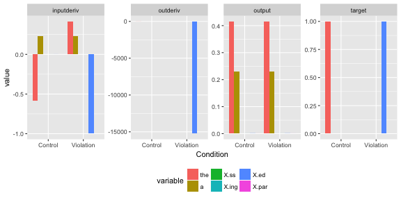

```r
showWordOutError("the,a,X.ss,X.ing,X.ed,X.par",c("Condition","measure"),postverb.df)
```

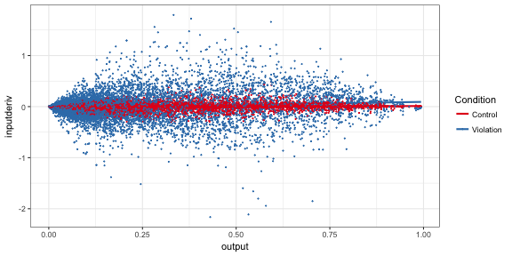

```r
corrHiddenOutputInputDeriv(postverb.df,"Condition")
```

```r
# make erp figure with different measures
mapping = aes(x=depth, y=value, colour = Condition,linetype=Condition)
norawpostverbnotargout.df=removeWordsDrawERP(postverb.df,mapping)
```

```
## [1] 6
```

```r
interactionText="NO TEXT"
modellist2 = list()
# get example for table
tenseexampleword = subset(norawpostverbnotargout.df,measure == mainMeasure  & layer == "word")
exampleTable = tenseexampleword[1:2,c("Condition","Example")]
tabletext = kable(exampleTable,format="latex",row.names=FALSE)
print(exampleTable)
```

```
##        Condition                                  Example
## 134046   Control      a father will drink the beer -s . .
## 134163 Violation  a father will drink -ed the beer -s . .
```

```r
 tenseinput  = subset(norawpostverbnotargout.df,measure == mainMeasure & layer %in% c("word",p600layer) )

if (nlevels(adultdata.df$sub) > 4){ # do mixed with more than 9 subj

  tenseinput$cviolation = ifelse(tenseinput$Condition=="Violation",0.5,-0.5) # one against two
  tenseinput$cp600layer = ifelse(tenseinput$layer==p600layer,0.5,-0.5)

  # this is the main mixed model with centered variables
  randomeff = paste(" + (1 +  cviolation*cp600layer |sub)")  # Condition*layer
  if (noslopes){ randomeff = " + (1 | sub)"}
  formu = as.formula(paste(dependMeasure,"~ cviolation*cp600layer",randomeff))
  omnimodel = lmer(formu, tenseinput,control=lmerControl(optimizer = "bobyqa",optCtrl=list(maxfun=50000)))
  print(summary(omnimodel))
  modellist2 = modelComparison(omnimodel) # create anova table

  # this model is for posthocs
  formu2 = as.formula(paste(dependMeasure,"~ Condition*layer",randomeff))
  omnimodelFactor = lmer(formu2, tenseinput)
  #print(summary(omnimodelFactor))
  model.lsmobj <- lsmeans(omnimodelFactor, ~ Condition | layer)
  posthocs = summary(as.glht(pairs(model.lsmobj)))
  print(posthocs)
  interactionText = printInteraction(posthocs)

}
```

```
## Linear mixed model fit by REML ['lmerMod']
## Formula:
## abssum ~ cviolation * cp600layer + (1 + cviolation * cp600layer |
##     sub)
##    Data: tenseinput
## Control: lmerControl(optimizer = "bobyqa", optCtrl = list(maxfun = 50000))
##
## REML criterion at convergence: 3647.5
##
## Scaled residuals:
##     Min      1Q  Median      3Q     Max
## -5.0214 -0.6388  0.0003  0.5295  7.0231
##
## Random effects:
##  Groups   Name                  Variance Std.Dev. Corr
##  sub      (Intercept)           0.1447   0.3804
##           cviolation            0.6981   0.8356   0.87
##           cp600layer            0.5832   0.7637   0.98 0.95
##           cviolation:cp600layer 2.4595   1.5683   0.94 0.99 0.99
##  Residual                       1.1648   1.0793
## Number of obs: 1200, groups:  sub, 10
##
## Fixed effects:
##                       Estimate Std. Error t value
## (Intercept)             2.7546     0.1243  22.170
## cviolation              3.1310     0.2715  11.534
## cp600layer              2.3415     0.2494   9.388
## cviolation:cp600layer   4.6014     0.5114   8.998
##
## Correlation of Fixed Effects:
##             (Intr) cviltn cp600l
## cviolation  0.819
## cp600layer  0.921  0.891
## cvltn:cp600 0.880  0.932  0.925
## [1] "remove . ~ . -  cviolation:cp600layer "
```

```
## refitting model(s) with ML (instead of REML)
```

```
## Data: tenseinput
## Models:
## model2: abssum ~ cviolation + cp600layer + (1 + cviolation * cp600layer |
## model2:     sub)
## model: abssum ~ cviolation * cp600layer + (1 + cviolation * cp600layer |
## model:     sub)
##        Df    AIC    BIC  logLik deviance  Chisq Chi Df Pr(>Chisq)
## model2 14 3688.9 3760.1 -1830.4   3660.9
## model  15 3667.9 3744.2 -1818.9   3637.9 22.996      1  1.623e-06 ***
## ---
## Signif. codes:  0 '***' 0.001 '**' 0.01 '*' 0.05 '.' 0.1 ' ' 1
## [1] "########## Above comparison for  cviolation:cp600layer  *** "
## [1] "remove . ~ . -  cp600layer "
```

```
## refitting model(s) with ML (instead of REML)
```

```
## Data: tenseinput
## Models:
## model2: abssum ~ cviolation + (1 + cviolation * cp600layer | sub)
## model: abssum ~ cviolation + cp600layer + (1 + cviolation * cp600layer |
## model:     sub)
##        Df    AIC    BIC  logLik deviance Chisq Chi Df Pr(>Chisq)
## model2 13 3687.7 3753.9 -1830.8   3661.7
## model  14 3688.9 3760.1 -1830.4   3660.9 0.845      1      0.358
## [1] "########## Above comparison for  cp600layer "
## [1] "remove . ~ . -  cviolation "
```

```
## refitting model(s) with ML (instead of REML)
```

```
## Data: tenseinput
## Models:
## model2: abssum ~ (1 + cviolation * cp600layer | sub)
## model: abssum ~ cviolation + (1 + cviolation * cp600layer | sub)
##        Df    AIC    BIC  logLik deviance  Chisq Chi Df Pr(>Chisq)
## model2 12 3691.2 3752.2 -1833.6   3667.2
## model  13 3687.7 3753.9 -1830.8   3661.7 5.4567      1    0.01949 *
## ---
## Signif. codes:  0 '***' 0.001 '**' 0.01 '*' 0.05 '.' 0.1 ' ' 1
## [1] "########## Above comparison for  cviolation  *** "
```

```
## Note: df set to 9
```

```
## $`layer = word`
##
##   Simultaneous Tests for General Linear Hypotheses
##
## Linear Hypotheses:
##                          Estimate Std. Error t value Pr(>|t|)
## Control - Violation == 0 -0.83035    0.09871  -8.412 1.48e-05 ***
## ---
## Signif. codes:  0 '***' 0.001 '**' 0.01 '*' 0.05 '.' 0.1 ' ' 1
## (Adjusted p values reported -- single-step method)
##
##
## $`layer = hidden`
##
##   Simultaneous Tests for General Linear Hypotheses
##
## Linear Hypotheses:
##                          Estimate Std. Error t value Pr(>|t|)
## Control - Violation == 0  -5.4317     0.5181  -10.48 2.41e-06 ***
## ---
## Signif. codes:  0 '***' 0.001 '**' 0.01 '*' 0.05 '.' 0.1 ' ' 1
## (Adjusted p values reported -- single-step method)
```

```
## [1] 6
```

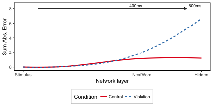

```r
  # figure for paper
  mapping = aes_string(x="depth", y=dependMeasure, colour = "Condition",linetype="Condition")
  drawERP(tenseinput,mapping, timeline.y=8,span=.8)
```

```r
  if (!noslopes){ # when doing final version, change noslopes to FALSE
    ggsave("img/tense.png",width=figwidth,height=figheight)
  }
```

CUT AND PASTE INTO LATEX DOC click in box and use right arrow to see whole text

```latex
This is an example of the stimuli used in the model.


\begin{tabular}{l|l}
\hline
Condition & Example\\
\hline
Control & a father will drink the beer -s . .\\
\hline
Violation & a father will drink -ed the beer -s . .\\
\hline
\end{tabular}
The maximal model for the data had random slopes  + (1 +  cviolation*cp600layer |sub)

Mixed Model Results
a main effect of cviolation ($\beta$=3.1, SE=0.27, $\chi^2$(1)=5.46, p=0.019)
no main effect of cp600layer ($\beta$=2.3, SE=0.25, $\chi^2$(1)=0.84, p=0.358)
@@an interaction of cviolation:cp600layer ($\beta$=4.6, SE=0.51, $\chi^2$(1)=23, p<0.001)
Posthoc tests for each layer
 @@Posthoc: There was a significant difference for layer = word, diff = 0.8303, t(9)=8.41, p<0.001
 @@Posthoc: There was a significant difference for layer = hidden, diff = 5.4317, t(9)=10.48, p<0.001
ratio  layer = hidden   6.5418523425268  rev  0.152861903271536
```

## WORDCAT (Wassenaar and Hagoort, 2005)

```r
write("wordcat", stderr())
cat.df = subset(adultdata.df,  str_detect(Condition,"(CATCONT|CATVIOL)") )
cat.df$Condition=factor(cat.df$Condition,labels=c("Control","Violation"))
verbpos = which(cat.df$wordcat == "VERBI")
wordcatsamelen = which(cat.df$wordcat!=cat.df$wordcat[1])[1]-1
verb.df = cat.df[verbpos,] #  verb
postverb.df = cat.df[verbpos + wordcatsamelen,] # position after verb
postverb.df=postverb.df[!is.na(postverb.df$Condition),]

print(head(postverb.df[postverb.df$measure=="target",c("word","wordcat","Condition","Example","tick")])) # check
```

```
##        word wordcat Condition                                    Example
## 113218   -s      PL   Control   the grandma was take -ing the nap -s . .
## 113348  -ed      ED Violation  the grandma was take -ing the nap -ed . .
## 147265   -s      PL   Control           the girl take -ed the nap -s . .
## 147382  -ed      ED Violation          the girl take -ed the nap -ed . .
## 160343   -s      PL   Control     a teacher was take -ing the nap -s . .
## 160473  -ed      ED Violation    a teacher was take -ing the nap -ed . .
##        tick
## 113218    8
## 113348    8
## 147265    7
## 147382    7
## 160343    8
## 160473    8
```

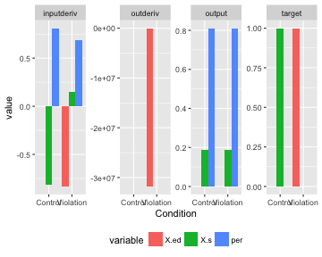

```r
showWordOutError("X.ed,X.s,per",c("Condition","measure"),postverb.df)
```

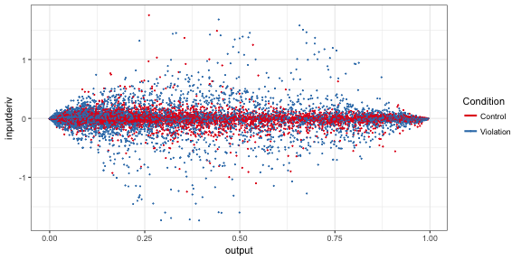

```r
corrHiddenOutputInputDeriv(postverb.df,"Condition")
```

```r
mapping = aes(x=depth, y=value, colour = Condition,linetype=Condition)
norawpostverbnotargout.df=removeWordsDrawERP(postverb.df,mapping)
```

```
## [1] 6
```

```r
interactionText="NO TEXT"
modellist2 = list()

# get example for table
catwordexample = subset(norawpostverbnotargout.df,measure == mainMeasure  & layer == "word")
exampleTable = catwordexample[1:4,c("Condition","Example")]
tabletext = kable(exampleTable,format="latex",row.names=FALSE)
print(exampleTable)
```

```
##        Condition                                    Example
## 113220   Control   the grandma was take -ing the nap -s . .
## 113350 Violation  the grandma was take -ing the nap -ed . .
## 147267   Control           the girl take -ed the nap -s . .
## 147384 Violation          the girl take -ed the nap -ed . .
```

```r
catinput  = subset(norawpostverbnotargout.df,measure == mainMeasure & layer %in% c("word",p600layer) )

if (nlevels(adultdata.df$sub) > 4){ # do mixed with more than 9 subj

  catinput$cviolation = ifelse(catinput$Condition=="Violation",0.5,-0.5) # one against two
  catinput$cp600layer = ifelse(catinput$layer==p600layer,0.5,-0.5)

  # this is the main mixed model with centered variables
  randomeff = paste(" + (1 + Condition * layer |sub)")
    if (noslopes){ randomeff = " + (1 | sub)" }
  formu = as.formula(paste(dependMeasure,"~ cviolation*cp600layer",randomeff))
  omnimodel = lmer(formu, catinput,control=lmerControl(optimizer = "bobyqa",optCtrl=list(maxfun=50000)))
  print(summary(omnimodel))
  modellist2 = modelComparison(omnimodel) # create anova table

  # this model is for posthocs
  formu2 = as.formula(paste(dependMeasure,"~ Condition*layer",randomeff))
  omnimodelFactor = lmer(formu2, catinput)
  #print(summary(omnimodelFactor))
  model.lsmobj <- lsmeans(omnimodelFactor, ~ Condition | layer)
  posthocs = summary(as.glht(pairs(model.lsmobj)))
  print(posthocs)
  interactionText = printInteraction(posthocs)

}
```

```
## Linear mixed model fit by REML ['lmerMod']
## Formula: abssum ~ cviolation * cp600layer + (1 + Condition * layer | sub)
##    Data: catinput
## Control: lmerControl(optimizer = "bobyqa", optCtrl = list(maxfun = 50000))
##
## REML criterion at convergence: 3708.1
##
## Scaled residuals:
##     Min      1Q  Median      3Q     Max
## -4.2596 -0.2688  0.0028  0.1206  7.8185
##
## Random effects:
##  Groups   Name                           Variance Std.Dev. Corr
##  sub      (Intercept)                    0.0000   0.0000
##           ConditionViolation             0.4319   0.6572     NaN
##           layerhidden                    0.5353   0.7316     NaN -0.28
##           ConditionViolation:layerhidden 4.7542   2.1804     NaN  0.26
##  Residual                                1.1874   1.0897
##
##
##
##
##  -0.55
##
## Number of obs: 1200, groups:  sub, 10
##
## Fixed effects:
##                       Estimate Std. Error t value
## (Intercept)             2.0250     0.1885  10.740
## cviolation              0.9010     0.4503   2.001
## cp600layer              0.7594     0.2978   2.550
## cviolation:cp600layer   1.7187     0.7009   2.452
##
## Correlation of Fixed Effects:
##             (Intr) cviltn cp600l
## cviolation  0.835
## cp600layer  0.800  0.598
## cvltn:cp600 0.707  0.870  0.719
## convergence code: 0
## unable to evaluate scaled gradient
## Model failed to converge: degenerate  Hessian with 1 negative eigenvalues
##
## [1] "remove . ~ . -  cviolation:cp600layer "
```

```
## refitting model(s) with ML (instead of REML)
```

```
## Data: catinput
## Models:
## model2: abssum ~ cviolation + cp600layer + (1 + Condition * layer | sub)
## model: abssum ~ cviolation * cp600layer + (1 + Condition * layer | sub)
##        Df    AIC    BIC  logLik deviance Chisq Chi Df Pr(>Chisq)
## model2 14 3728.5 3799.7 -1850.2   3700.5
## model  15 3732.7 3809.1 -1851.4   3702.7     0      1          1
## [1] "########## Above comparison for  cviolation:cp600layer "
## [1] "remove . ~ . -  cp600layer "
```

```
## refitting model(s) with ML (instead of REML)
```

```
## Data: catinput
## Models:
## model2: abssum ~ cviolation + (1 + Condition * layer | sub)
## model: abssum ~ cviolation + cp600layer + (1 + Condition * layer | sub)
##        Df    AIC    BIC  logLik deviance  Chisq Chi Df Pr(>Chisq)
## model2 13 3727.5 3793.7 -1850.8   3701.5
## model  14 3728.5 3799.7 -1850.2   3700.5 1.0421      1     0.3073
## [1] "########## Above comparison for  cp600layer "
## [1] "remove . ~ . -  cviolation "
```

```
## refitting model(s) with ML (instead of REML)
```

```
## Data: catinput
## Models:
## model2: abssum ~ (1 + Condition * layer | sub)
## model: abssum ~ cviolation + (1 + Condition * layer | sub)
##        Df    AIC    BIC  logLik deviance  Chisq Chi Df Pr(>Chisq)
## model2 12 3732.7 3793.8 -1854.3   3708.7
## model  13 3727.5 3793.7 -1850.8   3701.5 7.1576      1   0.007465 **
## ---
## Signif. codes:  0 '***' 0.001 '**' 0.01 '*' 0.05 '.' 0.1 ' ' 1
## [1] "########## Above comparison for  cviolation  *** "
```

```
## Note: df set to 9
```

```
## $`layer = word`
##
##   Simultaneous Tests for General Linear Hypotheses
##
## Linear Hypotheses:
##                          Estimate Std. Error t value Pr(>|t|)
## Control - Violation == 0  -0.0417     0.2261  -0.184    0.858
## (Adjusted p values reported -- single-step method)
##
##
## $`layer = hidden`
##
##   Simultaneous Tests for General Linear Hypotheses
##
## Linear Hypotheses:
##                          Estimate Std. Error t value Pr(>|t|)
## Control - Violation == 0  -1.7604     0.7747  -2.272   0.0492 *
## ---
## Signif. codes:  0 '***' 0.001 '**' 0.01 '*' 0.05 '.' 0.1 ' ' 1
## (Adjusted p values reported -- single-step method)
```

```
## [1] 6
```

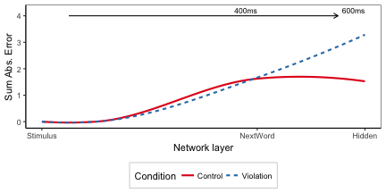

```r
  # figure for paper
  mapping = aes_string(x="depth", y=dependMeasure, colour = "Condition",linetype="Condition")
  drawERP(catinput,mapping, timeline.y=4,span=0.8)
```

```r
  if (!noslopes){ # when doing final version, change noslopes to FALSE¥n
    ggsave("img/cat.png",width=figwidth,height=figheight)
  }
```

CUT AND PASTE INTO LATEX DOC click in box and use right arrow to see whole text

```latex
This is an example of the stimuli used in the model.


\begin{tabular}{l|l}
\hline
Condition & Example\\
\hline
Control & the grandma was take -ing the nap -s . .\\
\hline
Violation & the grandma was take -ing the nap -ed . .\\
\hline
Control & the girl take -ed the nap -s . .\\
\hline
Violation & the girl take -ed the nap -ed . .\\
\hline
\end{tabular}
The maximal model for the data had random slopes  + (1 + Condition * layer |sub)

Mixed Model Results
a main effect of cviolation ($\beta$=0.9, SE=0.45, $\chi^2$(1)=7.16, p=0.0075)
no main effect of cp600layer ($\beta$=0.76, SE=0.3, $\chi^2$(1)=1.04, p=0.307)
@@no interaction of cviolation:cp600layer ($\beta$=1.7, SE=0.7, $\chi^2$(1)=0, p=1.000)
Posthoc tests for each layer
 @@Posthoc: There was no difference for layer = word, p=0.8577
 @@Posthoc: There was a significant difference for layer = hidden, diff = 1.7604, t(9)=2.27, p=0.0492
ratio  layer = hidden   42.2158273381295  rev  0.0236877982276755
```

## SUBCAT Osterhout and Holcomb (1992)

```r
write("subcat", stderr())
sub.df = subset(adultdata.df,  str_detect(Condition,"(SUBCONT|SUBVIOL)") )
sub.df$Condition=factor(sub.df$Condition,labels=c("Control","Violation"))
preppos = which(sub.df$word %in% c("near","by"))
prep.df = sub.df[preppos,] #  verb

print(head(prep.df[prep.df$measure=="target",c("word","wordcat","Condition","Example","tick")])) # check
```

```
##        word wordcat Condition                                   Example
## 109162 near    PREP   Control     a sister is nap -ing near the boy . .
## 109292 near    PREP Violation    a sister is take -ing near the boy . .
## 111021   by      BY   Control           the uncle -s walk by tea -s . .
## 111138   by      BY Violation          the uncle -s drink by tea -s . .
## 112555   by      BY   Control  a grandma jump -ed by the brother -s . .
## 112685   by      BY Violation   a grandma sip -ed by the brother -s . .
##        tick
## 109162    6
## 109292    6
## 111021    5
## 111138    5
## 112555    5
## 112685    5
```

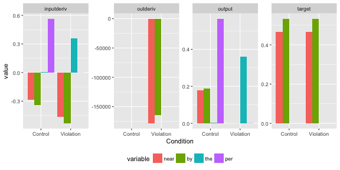

```r
showWordOutError("near,by,the,per",c("Condition","measure"),prep.df)
```

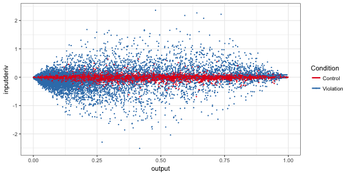

```r
corrHiddenOutputInputDeriv(prep.df,"Condition")
```

```r
mapping = aes(x=depth, y=value, colour = Condition,linetype=Condition)
norawprepnotargout.df=removeWordsDrawERP(prep.df,mapping)
```

```
## [1] 6
```

```r
interactionText="NO TEXT"
modellist2 = list()

# get example for table
catwordexample = subset(norawprepnotargout.df,measure == mainMeasure  & layer == "word")
exampleTable = catwordexample[1:4,c("Condition","Example")]
tabletext = kable(exampleTable,format="latex",row.names=FALSE)
print(exampleTable)
```

```
##        Condition                                 Example
## 109164   Control   a sister is nap -ing near the boy . .
## 109294 Violation  a sister is take -ing near the boy . .
## 111023   Control         the uncle -s walk by tea -s . .
## 111140 Violation        the uncle -s drink by tea -s . .
```

```r
subinput  = subset(norawprepnotargout.df,measure == mainMeasure & layer %in% c("word",p600layer) )

if (nlevels(adultdata.df$sub) > 4){ # do mixed with more than 9 subj

  subinput$cviolation = ifelse(subinput$Condition=="Violation",0.5,-0.5) # one against two
  subinput$cp600layer = ifelse(subinput$layer==p600layer,0.5,-0.5)

  # this is the main mixed model with centered variables
  randomeff = paste(" + (1 + cviolation*cp600layer |sub)")
    if (noslopes){ randomeff = " + (1 | sub)"}
  formu = as.formula(paste(dependMeasure,"~ cviolation*cp600layer",randomeff))
  omnimodel = lmer(formu, subinput,control=lmerControl(optimizer = "bobyqa",optCtrl=list(maxfun=50000)))
  print(summary(omnimodel))
  modellist2 = modelComparison(omnimodel) # create anova table

  # this model is for posthocs
  formu2 = as.formula(paste(dependMeasure,"~ Condition*layer",randomeff))
  omnimodelFactor = lmer(formu2, subinput)
  #print(summary(omnimodelFactor))
  model.lsmobj <- lsmeans(omnimodelFactor, ~ Condition | layer)
  posthocs = summary(as.glht(pairs(model.lsmobj)))
  print(posthocs)
  interactionText = printInteraction(posthocs)
}
```

```
## Linear mixed model fit by REML ['lmerMod']
## Formula:
## abssum ~ cviolation * cp600layer + (1 + cviolation * cp600layer |
##     sub)
##    Data: subinput
## Control: lmerControl(optimizer = "bobyqa", optCtrl = list(maxfun = 50000))
##
## REML criterion at convergence: 4511.8
##
## Scaled residuals:
##     Min      1Q  Median      3Q     Max
## -6.0550 -0.2155  0.0002  0.0798  7.8464
##
## Random effects:
##  Groups   Name                  Variance Std.Dev. Corr
##  sub      (Intercept)           0.5597   0.7481
##           cviolation            2.0680   1.4381   0.99
##           cp600layer            2.2341   1.4947   1.00 0.99
##           cviolation:cp600layer 8.2793   2.8774   0.99 1.00 0.99
##  Residual                       2.4064   1.5513
## Number of obs: 1200, groups:  sub, 10
##
## Fixed effects:
##                       Estimate Std. Error t value
## (Intercept)             3.2931     0.2408  13.676
## cviolation              3.6788     0.4635   7.937
## cp600layer              2.9511     0.4811   6.134
## cviolation:cp600layer   6.6299     0.9274   7.149
##
## Correlation of Fixed Effects:
##             (Intr) cviltn cp600l
## cviolation  0.958
## cp600layer  0.965  0.958
## cvltn:cp600 0.958  0.963  0.959
## [1] "remove . ~ . -  cviolation:cp600layer "
```

```
## refitting model(s) with ML (instead of REML)
```

```
## Data: subinput
## Models:
## model2: abssum ~ cviolation + cp600layer + (1 + cviolation * cp600layer |
## model2:     sub)
## model: abssum ~ cviolation * cp600layer + (1 + cviolation * cp600layer |
## model:     sub)
##        Df    AIC    BIC  logLik deviance  Chisq Chi Df Pr(>Chisq)
## model2 14 4551.7 4623.0 -2261.8   4523.7
## model  15 4534.7 4611.1 -2252.4   4504.7 18.976      1  1.324e-05 ***
## ---
## Signif. codes:  0 '***' 0.001 '**' 0.01 '*' 0.05 '.' 0.1 ' ' 1
## [1] "########## Above comparison for  cviolation:cp600layer  *** "
## [1] "remove . ~ . -  cp600layer "
```

```
## refitting model(s) with ML (instead of REML)
```

```
## Data: subinput
## Models:
## model2: abssum ~ cviolation + (1 + cviolation * cp600layer | sub)
## model: abssum ~ cviolation + cp600layer + (1 + cviolation * cp600layer |
## model:     sub)
##        Df    AIC    BIC  logLik deviance  Chisq Chi Df Pr(>Chisq)
## model2 13 4550.8 4616.9 -2262.4   4524.8
## model  14 4551.7 4623.0 -2261.8   4523.7 1.0741      1        0.3
## [1] "########## Above comparison for  cp600layer "
## [1] "remove . ~ . -  cviolation "
```

```
## refitting model(s) with ML (instead of REML)
```

```
## Data: subinput
## Models:
## model2: abssum ~ (1 + cviolation * cp600layer | sub)
## model: abssum ~ cviolation + (1 + cviolation * cp600layer | sub)
##        Df    AIC    BIC  logLik deviance Chisq Chi Df Pr(>Chisq)
## model2 12 4553.0 4614.1 -2264.5   4529.0
## model  13 4550.8 4616.9 -2262.4   4524.8 4.225      1    0.03983 *
## ---
## Signif. codes:  0 '***' 0.001 '**' 0.01 '*' 0.05 '.' 0.1 ' ' 1
## [1] "########## Above comparison for  cviolation  *** "
```

```
## Note: df set to 9
```

```
## $`layer = word`
##
##   Simultaneous Tests for General Linear Hypotheses
##
## Linear Hypotheses:
##                          Estimate Std. Error t value Pr(>|t|)
## Control - Violation == 0  -0.3639     0.1267  -2.872   0.0184 *
## ---
## Signif. codes:  0 '***' 0.001 '**' 0.01 '*' 0.05 '.' 0.1 ' ' 1
## (Adjusted p values reported -- single-step method)
##
##
## $`layer = hidden`
##
##   Simultaneous Tests for General Linear Hypotheses
##
## Linear Hypotheses:
##                          Estimate Std. Error t value Pr(>|t|)
## Control - Violation == 0  -6.9938     0.9185  -7.614 3.28e-05 ***
## ---
## Signif. codes:  0 '***' 0.001 '**' 0.01 '*' 0.05 '.' 0.1 ' ' 1
## (Adjusted p values reported -- single-step method)
```

```
## [1] 6
```

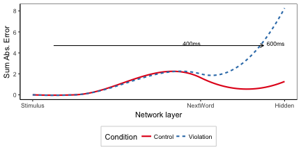

```r
  # figure for paper
  longnoraw2 = subset(norawprepnotargout.df,measure == mainMeasure )
    mapping = aes_string(x="depth", y=dependMeasure, colour = "Condition",linetype="Condition")
  drawERP(longnoraw2,mapping, timeline.y=4.7)
```

```r
  if (!noslopes){ # when doing final version, change noslopes to FALSE
    ggsave("img/subjcat.png",width=figwidth,height=figheight)
  }
```

CUT AND PASTE INTO LATEX DOC click in box and use right arrow to see whole text

```latex
This is an example of the stimuli used in the model.


\begin{tabular}{l|l}
\hline
Condition & Example\\
\hline
Control & a sister is nap -ing near the boy . .\\
\hline
Violation & a sister is take -ing near the boy . .\\
\hline
Control & the uncle -s walk by tea -s . .\\
\hline
Violation & the uncle -s drink by tea -s . .\\
\hline
\end{tabular}
The maximal model for the data had random slopes  + (1 + cviolation*cp600layer |sub)

Mixed Model Results
a main effect of cviolation ($\beta$=3.7, SE=0.46, $\chi^2$(1)=4.23, p=0.040)
no main effect of cp600layer ($\beta$=3, SE=0.48, $\chi^2$(1)=1.07, p=0.300)
@@an interaction of cviolation:cp600layer ($\beta$=6.6, SE=0.93, $\chi^2$(1)=18.98, p<0.001)
Posthoc tests for each layer
 @@Posthoc: There was a significant difference for layer = word, diff = 0.3639, t(9)=2.87, p=0.0184
 @@Posthoc: There was a significant difference for layer = hidden, diff = 6.9938, t(9)=7.61, p<0.001
ratio  layer = hidden   19.2190162132454  rev  0.052031799593926
```